# Spark guide

# page

## Начало работы

### Обзор средств взаимодействия со Spark

*Spark* – проект *Apache*, предназначенный для кластерных вычислений, представляет собой быструю и универсальную среду для обработки данных, в том числе и для машинного обучения. *Spark* также имеет *API* и для *R* (пакет *SparkR*), который входит в сам дистрибутив *Spark*. Но, помимо работы с данным *API*, имеется еще два альтернативных способа работы со *Spark* в *R*. Итого, существует три различных способа взаимодействия с кластером *Spark*.

Помимо официального пакета *SparkR*, возможности в машинном обучении которого слабы (в версии 1.6.2 всего одна модель, в версии 2.0.0 их четыре), имеется еще два варианта доступа к Spark.

Первый вариант — это использование продукта от *Microsoft* — *Microsoft R Server for Hadoop*, в который недавно была интегрирована поддержка *Spark*. Используя данный продукт, можно производить вычисления по одним и тем же функциям *R*, в контексте локальных вычислений, *Hadoop (map-reduce)* или *Spark*. Помимо локальной установки *R* и доступа к кластеру *Spark*, облачная служба *Microsoft Azure HDInsight* позволяет развернуть готовые кластеры, и, кроме обычного кластера *Spark*, имеется возможность развернуть кластер *R Server on Spark*. Данный сервис представляет собой кластер *Spark* с предустановленным *R server for Hadoop* на дополнительном, пограничном узле, что позволяет сразу производить вычисления, как локально на данном сервере, так и переключаться на контекст *Spark* или *Hadoop*. Использование данного продукта достаточно хорошо описано в официальной документации к *HDInsight* на сайте *Microsoft*.

Второй вариант - это использование нового пакета *sparklyr*, который пока находится в стадии разработки. Этот продукт разрабатывается под эгидой *RStudio* — компании, под крылом которой выпущены одни из самых полезных и необходимых пакетов – *knitr, ggplot2, tidyr, lubridate, dplyr* и другие, поэтому этот пакет может стать еще одним лидером. Пока данный пакет слабо документирован, так как еще официально не выпущен.

На основе документации каждого из этих способов работы со *Spark*, представлена следующая таблица *(Табл. 1)* с обобщенными функциональными возможностями каждого из способов (также *SparkR 2.0.0*, в котором возможностей стало чуть больше).

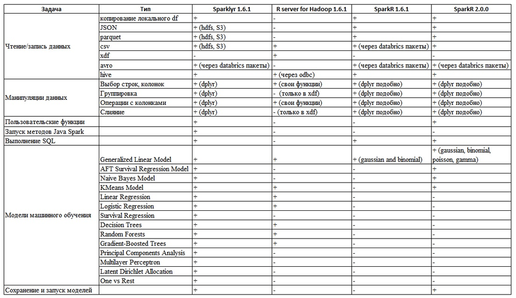

Как видно из таблицы, нет ни одного средства в полной мере реализующие необходимые потребности «из коробки», но пакет *sparklyr* выгодно отличается от *SparkR* и *R* Server. Основные его достоинства – чтение *csv, json, parquet* файлов из *hdfs*. Полностью совместимый с *dplyr* синтаксис манипулирования данными – включающий в себя операции фильтрации, выбора колонок, агрегирующие функции, возможности выполнять слияние данных, модификацию имен колонок и многое другое. В отличии от *SparkR* или *R server for Hadoop*, где некоторые из этих задач либо не выполняются, либо выполняются очень неудобно.

### Установка sparklyr

Для начала пользования на автономном компьютере, вам нужно либо загрузить и устонивить новую версию *RStudio Preview*, либо выполнить следующую последовательность команд в оболочке *RStudio*:

```
install.packages("sparklyr")
```

Для взаимодействия со *Spark* вам потребуется установить локальную версию *Spark*, а также установить пакеты *readr* и *digest*, если они не установлены:

```
install.packages("readr")
install.packages("digest")
library(sparklyr)
spark_install(version = "2.1.0")
```

Чтобы обновить *sparklyr* до последней версии, выполните следующую команду и перезапугрузите *r* сессию:

```
devtools::install_github("rstudio/sparklyr")
```

После выполнения всех необходимых пунктов по установке пакета *sparklyr* можно подключаться как к локальным экземплярам Spark, так и к удаленным кластерам Spark.

### Подключение к локальному экземпляру Spark

Локальный режим - отличный способ научиться и поэкспериментировать со *Spark*. Он также обеспечивает удобную среду разработки для анализа, создания отчетов и прилодений, которые вы планируете развернуть в многоузловом *Spark-кластере*.

В приведенном ниже коде подключение производится к локальному экземпляру *Spark* через функцию *spark_connect*:

```
library(sparklyr)
sc <- spark_connect(master = "local")
```

Возвращенное соединение *Spark* (*sc*) обеспечивает удаленное управление источником данных с помощью пакета *dplyr* на *Spark* кластере. Подключение к *Spark* можно настроить, установив значения определнных свойств *Spark*. В *sparklyr* свойоства *Spark* могут быть заданы с помощью аргумента *config* в функции *spark_connect*. Ниже приведены рекомендуемые свойства *Spark* для установки подключения через *R*:

- sparklyr.cores.local - количество ядер, которые будут задействованы *Spark*. По умолчанию используются все доступные ядра. Не обязательно устанавливать это свойство, если нет причин использовать меньше ядер, чем доступно для данного сеанса *Spark*.
- sparklyr.shell.driver-memory - объем оперативной памяти. По умолчанию - это весь доступный объем ОП на компьютере, минус то, что потребуется для операций OS.
- spark.memory.fraction - по умолчанию установлено 60% запрошенной памяти для каждого исполняемого действия.

**Пример подключения**

```
conf <- spark_config() # Load variable with spark_config()

conf$`sparklyr.cores.local` <- 4
conf$`sparklyr.shell.driver-memory` <- "16G"
conf$spark.memory.fraction <- 0.9

sc <- spark_connect(master = "local",
                    version = "2.1.0",
                    config = conf)
```

### Подключение к удаленным кластерам Spark

Вначале разворачиваем кластер *Spark*. После успешного разворачивания кластера, используя подключение по *SHH* к рабочему узлу, устанавливаем туда *R* и *RStudio*, с необходимыми зависимостями. *RStudio* желательно использовать *preview* редакции, так как в ней появились допольнительные возможности для пакета *sparklyr* - дополнительное окно, в котором отображаются исходные датафреймы в *Spark*, и возможность просмотреть их свойства или их самих. После установки *R*, *RStudio*, переустанавливаем соединение, используя тунелирование на *localhost:8787*. Итак, теперь в браузере по адресу *localhost:8787* мы подключаемся к *RStudio* и продложаем работать.

В настоящее время нет хорошего способа централизованно управлять пользовательскими подключениями к службе *Spark*. Существуют некоторые ограничения и настройки, которые могут применяться, но в большинстве случаев конфигурации подключения, пользователь *R* должен настроить сам.

Страница [Running on YARN](https://spark.apache.org/docs/latest/running-on-yarn.html) на официальном веб-сайте *Spark* - это лучшее место для начала настройки параметров конфигурации, пожалуйста, добавьте ее в закладки. Администраторы кластеров и пользователи могут извлечь выгоду из этого документа.

Пример подключения, когда в качестве значения для главного аргумента в *spark_connect()* указано *yarn-client*:

```
conf <- spark_config()

conf$spark.executor.memory <- "300M"
conf$spark.executor.cores <- 2
conf$spark.executor.instances <- 3
conf$spark.dynamicAllocation.enabled <- "false"

sc <- spark_connect(master = "yarn-client",
                    spark_home = "/usr/lib/spark/",
                    version = "1.6.0",
                    config = conf)
```

##### Yarn и для чего он нужен

*Yarn* - это кластер менеджер, который можно использовать для распределения задач *Spark* по всему кластеру. Когда пишется какой-то код, работающий, например, с *jdbc* или *ORM*, фактически что происходит? Есть машина, которая запускает *Java*-процесс, и когда в этом процессе бежит код, обращающийся к базе данных, все данные вычитываются из БД и перегоняется туда, где работает этот *Java*-процесс. Когда мы говорим про *big data*, это сделать невозможно, потому что данных слишком много — это неэффективно и у нас образуется горлышко бутылки. Кроме того, *data* и так уже распределенная и изначально находится на большом количестве машин, поэтому правильнее не *data* тянуть к этому процессу, а код распределять на те машины, на которых мы хотим эту «дату» обрабатывать. Соответственно, это происходит параллельно на многих машинах, мы задействуем неограниченное количество ресурсов, и вот здесь нам нужен кластер-менеджер, который будет координировать эти процессы.

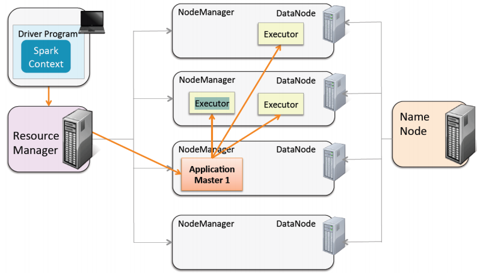

*Driver* — это *main*, который запускается на отдельной машине (не имеющей отношения к кластеру). Когда мы сабмитим наше *Spark*-приложение, мы обращаемся к *Yarn*, который является ресурс-менеджером. Мы ему говорим, сколько *worker*-ов задействовать под наш *Java*-процесс (например, 3). Он из кластерных машин выбирает одну машину, которая будет называться *Application Master*. Ее задача — получить код и найти в кластере три машины для его выполнения. Находятся три машины, поднимаются три отдельных Java-процесса (три *executor*-а), где запускается код. Потом это все возвращается *Application Master*, и в конечном итоге он возвращает это напрямую на *Driver*, если мы хотим результат операции над *big data* получить обратно туда, откуда код вышел.

## Манипуляции с данными

*dplyr* - это пакет *R*, предназначенный для работы со структурированными данными. С помощью dplyr манипуляции с данными становятся легкими, последовательными и эффективными. С *dplyr* в качестве интерфейса для управления *Spark DataFrames* вы можете:

- Выбрать, отфильтровать и агрегировать данные
- Использовать оконные функции
- Соединять датафреймы
- Коллектить данные из *Spark* в *R*

### Чтение и запись данных

Вы можете читать данные в *Spark DataFrames*, используя следующие функции:

| **Функция** | **Описание** |
| --- | --- |
| spark_read_csv | Считывает CSV-файл и предоставляет источник данных, совместимый с dplyr |
| spark_read_json | Читает файл JSON и предоставляет источник данных, совместимый с dplyr |
| spark_read_parquet | Читает файл паркета и предоставляет источник данных, совместимый с dplyr |

Независимо от формата ваших данных, *Spark* поддерживает чтение данных из разных источников данных. К ним относятся данные, хранящиеся в HDFS (протокол hdfs: //), Amazon S3 (протокол s3n: //) или локальные файлы, доступные для рабочих узлов Spark (файл: // протокол)

Пример чтения файла паркета в текущей сессии *Spark*:

```
new_tbl <- spark_read_parquet(sc=sc, name = "data", path = "hdfs://hdfs.company.org:9000/hdfs-path/data", memory = T, overwrite = T)
```

Aргумент *memory* для функции *spark_read…* отвечает за то будут ли данные загружены в память как RDD. Установка его в FALSE означает, что Spark по существу отобразит файл, но не сделает его копию в памяти. Это заставляет команду *spark_read…* работать быстрее, но компромисс заключается в том, что любые операции преобразования данных будут занимать гораздо больше времени.

часто полезно сохранять результаты вашего анализа или таблицы, которые были сгенерированы в вашем Spark-кластере, в постоянное хранилище. Лучшим вариантом во многих сценариях является запись таблицы в файл Parquet с использованием функции *spark_write_parquet*. Например:

```
spark_write_parquet(tbl, "hdfs://hdfs.company.org:9000/hdfs-path/data")
```

Вы также можете сохранять данные в CSV формате или JSON, используя функции *spark_write_csv* и *spark_write_json*.

### Обработка данных на примере flights data

Ниже продемонстрированы некторые из основных глаголов обработки данных пакета *dplyr* над данными из пакета *nycflights13*. Этот пакет содержит данные для всех 336 776 рейсов, вылетавших из Нью-Йорка в 2013 году. Он также включает полезные метаданные о аэропортах, погоде и самолетах. Данные поступают из Бюро статистики транспорта США и документируются в журнале *nycflights13*.

Подключитесь к кластеру и скопируйте данные рейсов с помощью функции *copy_to*. Данные полетов из *nycflights13* удобны для демонстраций *dplyr*, потому что они небольшие, но на практике большие данные редко копируются непосредственно из объектов R.

```
library(sparklyr)
library(dplyr)
library(nycflights13)
library(ggplot2)

sc <- spark_connect(master="local")
flights <- copy_to(sc, flights, "flights", overwrite = T)
airlines <- copy_to(sc, airlines, "airlines", overwrite = T)
src_tbls(sc)
```

#### Основные команды dplyr

Глаголы - это команды *dplyr* для управления данными. При подключении к *Spark DataFrame, dplyr* переводит команды в операторы *Spark SQL*. В удаленных источниках данных используются те же пять глаголов, что и в локальные источники данных. Вот пять глаголов с соответствующими командами *SQL*:

- select ~ SELECT
- filter ~ WHERE
- arrange ~ ORDER BY
- summarise ~ aggregators: sum, min, sd, etc.
- mutate ~ operators: +, *, log, etc.

```
flights %>% select(year:day, arr_delay, dep_delay)
flights %>% filter(dep_delay > 1000)
flights %>% arrange(desc(dep_delay))
flights %>% summarise(mean_dep_delay = mean(dep_delay))
flights %>% mutate(speed = distance / air_time * 60)
```

При работе с базами данных *dplyr* пытается быть настолько ленивым, насколько это возможно:

- Он никогда не извлекает данные в R, если вы явно не попросите об этом.
- Он задерживает выполнение любой работы до последнего момента: он собирает все, что вы хотите сделать, и затем отправляет команду в базу данных за один шаг.

Например, выполните следующий код:

```
c1 <- filter(flights, day == 17, month == 5, carrier %in% c('UA', 'WN', 'AA', 'DL'))
c2 <- select(c1, year, month, day, carrier, dep_delay, air_time, distance)
c3 <- arrange(c2, year, month, day, carrier)
c4 <- mutate(c3, air_time_hours = air_time / 60)
```

Эта последовательность операций никогда не затрагивает базу данных. Только когда вы запрашиваете данные (например, путем печати *c4*), *dplyr* запрашивает результаты из базы данных.

Используя тот же пример сверху, вы можете написать гораздо более чистую версию:

```
c4 <- flights %>%
  filter(month == 5, day == 17, carrier %in% c('UA', 'WN', 'AA', 'DL')) %>%
  select(carrier, dep_delay, air_time, distance) %>%
  arrange(carrier) %>%
  mutate(air_time_hours = air_time / 60)
```

#### Группировка данных

Функция group_by соответствует оператору GROUP BY в SQL.

```
c4 %>%
  group_by(carrier) %>%
  summarize(count = n(), mean_dep_delay = mean(dep_delay))
```

#### Сбор данных

Вы можете копировать данные из *Spark* в память *R*, используя команду *collect()*.

```
carrierhours <- collect(c4)
```

При получении команды *collect ()*, Spark выполнит инструкцию *SQl* и отправит результат обратно в *R* в виде датасета.

#### Оконные функции

*dplyr* поддерживает оконныые функции *Spark SQL*. Оконные функции используются совместно с *mutate* и *filter* для решения широкого круга проблем. Вы можете сравнить синтаксис *dplyr* с запросом, который он сгенерировал, используя *dbplyr :: sql_render ()*.

```
# Rank each flight within a daily
ranked <- flights %>%
  group_by(year, month, day) %>%
  select(dep_delay) %>%
  mutate(rank = rank(desc(dep_delay)))
dbplyr::sql_render(ranked)
```

#### Объединение таблиц

В *dplyr* существует три семейства глаголов, которые работают с двумя таблицами одновременно:

- Мутирующие объединения, которые добавляют новые переменные в одну таблицу из совпадающих строк в другой.
- Фильтрация соединений, которые фильтруют наблюдения из одной таблицы в зависимости от того, соответствуют ли они наблюдению в другой таблице.
- Установите операции, которые объединяют наблюдения в наборах данных, как если бы они были элементами набора.

Все two-table глаголы работают аналогично. Первые два аргумента - это x и y и представляют таблицы для объединения. Вывод всегда представляет собой новую таблицу с тем же типом, что и x.

Следующие команды эквивалентны:

```
flights %>% left_join(airlines)
```

```
flights %>% left_join(airlines, by = "carrier")
```

```
flights %>% left_join(airlines, by = c("carrier", "carrier"))
```

#### Выделение части данных

Вы можете использовать *sample_n ()* и *sample_frac ()* для получения произвольной выборки строк: *sample_n ()* используется для выделения фиксированного числа строк, а *sample_frac ()* для фиксированной доли строк.

#### Регистрация полученного датасета в Spark

*sdf_register* зарегистрирует полученный *Spark SQL* в *Spark.* Результаты будут отображаться в виде таблицы, называемой *flight_spark.* Но одноименная таблица все еще не будет загружена в память Spark.

```
sdf_register(flights_table, "flights_spark")
```

## Spark ML

*sparklyr* обеспечивает привязку к распределенной библиотеке машинного обучения *Spark*. В частности, *sparklyr* позволяет вам получить доступ к процедурам машинного обучения, предоставляемым пакетом *spark.ml*. Вместе с интерфейсом *dplyr* от *sparklyr* вы можете легко создавать и настраивать рабочие процессы машинного обучения на *Spark*, организованные полностью внутри *R*.

*sparklyr* предоставляет три семейства функций, которые вы можете использовать при обучении *Spark*:

- Алгоритмы машинного обучения для анализа данных *(ml_)*
- Функциональные трансформаторы для управления отдельными функциями *(ft_)*
- Функции для управления* Spark DataFrames* *(sdf_)*

Аналитический рабочий процесс с *sparklyr* может состоять из следующих этапов.

1. Выполнить *SQL*-запросы через интерфейс *sparklyr* *dplyr*
2. Использовать семейство функций *sdf_* и *ft_* для создания новых столбцов или разделения вашего набора данных
3. Выбрать подходящий алгоритм машинного обучения из семейства функций *ml_* для моделирования ваших данных
4. Проверьте качество вашей модели и используйте ее для создания прогнозов с новыми данными
5. Соберите результаты для визуализации и дальнейшего анализа в *R*

| **Алгоритм** | **Описание** |
| --- | --- |
| ml_kmeans | K-Means Clustering |
| ml_linear_regression | Linear Regression |
| ml_logistic_regression | Logistic Regression |
| ml_survival_regression | Survival Regression |
| ml_generalized_linear_regression | Generalized Linear Regression |
| ml_decision_tree | Decision Trees |
| ml_random_forest | Random Forests |
| ml_gradient_boosted_trees | Gradient-Boosted Trees |
| ml_pca | Principal Components Analysis |
| ml_naive_bayes | Naive-Bayes |
| ml_multilayer_perceptron | Multilayer Perceptron |
| ml_lda | Latent Dirichlet Allocation |
| ml_one_vs_rest | One vs Rest |

*Spark* предоставляет функциональные трансформаторы, облегчающие большинство преобразований данных в *Spark DataFrame*, а *sparklyr* предоставляет их в семействе функций *ft_*. Эти процедуры обычно берут один или несколько входных столбцов и генерируют новый выходной столбец, сформированный из преобразование этих столбцов.

| **Функция** | **Описание** |
| --- | --- |
| ft_binarizer | Пороговые числовые функции для двоичной (0/1) функции |
| ft_bucketizer | Преобразует столбец непрерывных функций в столбец признаков |
| ft_discrete_cosine_transform | Преобразует вещественную последовательность длины NN во временной области в другую длину NN-вещественную последовательность в частотной области |
| ft_elementwise_product | Умножает каждый входной вектор на предоставленный вектор, используя умножение по элементам |
| ft_index_to_string | Отображает столбец индексов обратно в столбец, содержащий исходные метки в виде строк |
| ft_quantile_discretizer | Принимает столбец с непрерывными функциями и выводит столбец со строгими категориальными функциями |
| sql_transformer | Осуществляет преобразования, которые определяются оператором SQL |
| ft_string_indexer | Кодирует строковый столбец меток в столбец индексов |
| ft_vector_assembler | Объединение заданного списка столбцов в один векторный столбец |

### Пример рабочего процесса

Простой пример, чтобы продемонстрировать использование алгоритмов машинного обучения *Spark* в *R*. Мы будем использовать *ml_linear_regression* для соответствия модели линейной регрессии. Используем встроенный набор данных *mtcars*, мы постараемся предсказать расход топлива на автомобиль (mpg) на основе его веса (wt) И количества цилиндров, которые содержит двигатель (cyl).

Сначала установим соединение с локальным *Spark* в *R*

```r
library(sparklyr)
library(dplyr)
```

```r
library(nycflights13)
library(ggplot2)

sc <- spark_connect(master="local")
```

```
## * Using Spark: 2.0.0
```

Скопируем набор данных *mtcars* в *Spark.*

```r
mtcars_tbl <- copy_to(sc, mtcars, "mtcars")
```

Преобразуем данные с помощью *Spark SQL*, функциональных трансформаторов и функций *DataFrame.*

1. Используем *Spark SQL* для удаления всех автомобилей с лошадиной силой менее 100
2. Используем трансформаторы функции *Spark* для ковша автомобилей в две группы на основе цилиндров
3. Используем функции *Spark DataFrame* для разделения данных на тестовые и обучающие

Затем применим линейную модель с использованием *Spark ML*. Модель *MPG* как функция веса и цилиндров.

```r
# transform our data set, and then partition into 'training', 'test'
partitions <- mtcars_tbl %>%
  filter(hp >= 100) %>%
  sdf_mutate(cyl8 = ft_bucketizer(cyl, c(0,8,12))) %>%
  sdf_partition(training = 0.5, test = 0.5, seed = 888)

# fit a linear mdoel to the training dataset
fit <- partitions$training %>%
  ml_linear_regression(mpg ~ wt + cyl)
```

```r
# summarize the model
summary(fit)
```

```
## Deviance Residuals:
##     Min      1Q  Median      3Q     Max
## -2.0947 -1.2747 -0.1129  1.0876  2.2185
##
## Coefficients:
## (Intercept)          wt         cyl
##   33.795576   -1.596247   -1.580360
##
## R-Squared: 0.8267
## Root Mean Squared Error: 1.437
```

В *summary()* показано, что наша модель достаточно хороша, и что вес автомобиля, а также количество цилиндров в его двигателе станут мощными предикторами его среднего расхода топлива. (Модель предполагает, что в среднем более тяжелые автомобили потребляют больше топлива.)

Давайте используем нашу модель *Spark* для прогнозирования среднего расхода топлива в нашем наборе тестовых данных и сравним прогнозируемый отклик с истинным измеренным расходом топлива. Мы построим простой график *ggplot2*, который позволит нам проверить качество наших прогнозов.

```r
# Score the data
pred <- sdf_predict(fit, partitions$test) %>%
  collect
```

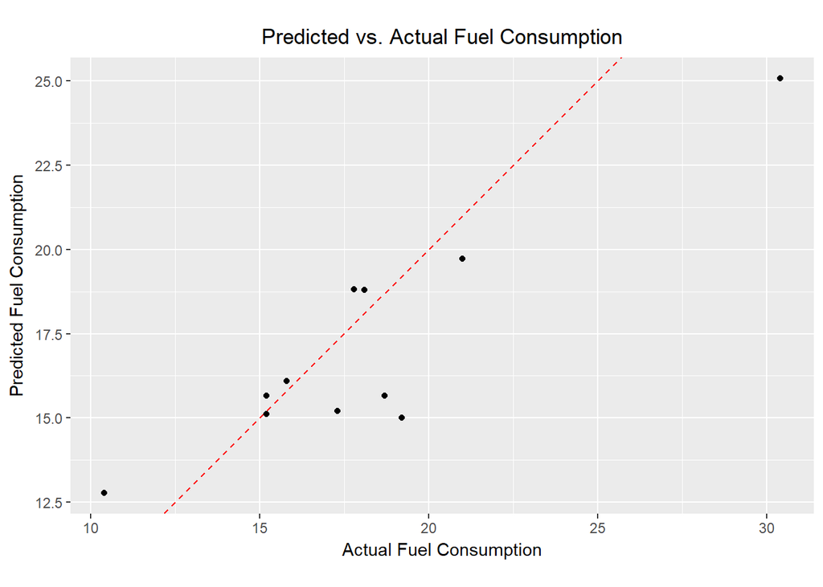

```r
# Plot the predicted versus actual mpg
ggplot(pred, aes(x = mpg, y = prediction)) +
  geom_abline(lty = "dashed", col = "red") +
  geom_point() +
  theme(plot.title = element_text(hjust = 0.5)) +
  coord_fixed(ratio = 1) +
  labs(
    x = "Actual Fuel Consumption",
    y = "Predicted Fuel Consumption",
    title = "Predicted vs. Actual Fuel Consumption"
  )
```

Несмотря на простоту, наша модель, похоже, довольно неплохо предсказывает средний расход топлива на автомобиль.

## Применение функций R к объекту Spark

*sparklyr* обеспечивает поддержку для запуска произвольного *R*-кода внутри вашего *Spark Cluster* через функцию *spark_apply ()*. Это особенно полезно, когда необходимо использовать функциональные возможности, доступные только в пакетах *R* или в самом *R*, которые недоступны в *Apache Spark* или *Spark Packages*.

*spark_apply ()* применяет функцию *R* к объекту *Spark* (как правило, *Spark DataFrame*). Объекты *Spark* разбиты на разделы, чтобы их можно было распределить по кластеру. Вы можете использовать *spark_apply* с разделами по умолчанию, или вы можете определить свои собственные разделы с аргументом *group_by.* Ваша функция *R* должна вернуть еще один *Spark DataFrame*. *spark_apply* будет запускать вашу функцию *R* на каждом разделе и выводить один *Spark DataFrame*.

Функция *R*, переданная в *spark_apply*, ожидает *DataFrame* и вернет объект, который может быть передан как *DataFrame*. Например, применим функцию *class* через *spark_apply()*:

```
sdf_len(sc, 10, repartition = 1) %>%
  spark_apply(function(e) class(e))
```

*Spark* разбивает данные на хэш или диапазон так, чтобы датафрейм мог быть распределен по кластеру. В следующем примере мы создадим два раздела и подсчитаем количество строк в каждом разделе. Затем выведем первую запись в каждом разделе.

```r
trees_tbl <- sdf_copy_to(sc, trees, repartition = 2)

trees_tbl %>%
  spark_apply(function(e) nrow(e), names = "n")
```

```
## # Source:   table<sparklyr_tmp_3e0982ad56394> [?? x 1]
## # Database: spark_connection
##       n
##   <int>
## 1    15
## 2    16
```

```r
trees_tbl %>%
  spark_apply(function(e) head(e, 1))
```

```
## # Source:   table<sparklyr_tmp_3e0984be1194f> [?? x 3]
## # Database: spark_connection
##   Girth Height Volume
##   <dbl>  <dbl>  <dbl>
## 1   8.3     70   10.3
## 2  12.9     74   22.2
```

Мы можем применить любую произвольную функцию к разделам в *Spark DataFrame*. Например, добавить шум к каждому столбцу. Обратите внимание, что *spark_apply* применяет функцию R ко всем разделам и возвращает один *DataFrame.*

```
trees_tbl %>%
  spark_apply(function(e) sapply(e, jitter))
```

По умолчанию *spark_apply ()* выводит имена столбцов из входного фрейма данных *Spark.* Используйте аргумент *names* для переименования или добавления новых столбцов.

```
trees_tbl %>%
  spark_apply(
    function(e) data.frame(2.54 * e$Girth, e),
    names = c("Girth(cm)", colnames(trees)))
```

Вы можете применить функцию *R* к определенным группам в своих данных. Например, предположим, что вы хотите вычислить линейную регрессию для конкретных подгрупп. Чтобы решить эту проблему, вы можете указать аргумент *group_by*. Этот пример подсчитывает количество строк в датасете *iris* по *species* и затем применяет модель линейной регресси для каждого *species*.

```r
iris_tbl <- sdf_copy_to(sc, iris)

iris_tbl %>%
  spark_apply(nrow, group_by = "Species")
```

```
## # Source:   table<sparklyr_tmp_3e09859596701> [?? x 2]
## # Database: spark_connection
##   Species    Sepal_Length
##   <chr>             <int>
## 1 versicolor           50
## 2 virginica            50
## 3 setosa               50
```

```r
iris_tbl %>%
  spark_apply(
    function(e) summary(lm(Petal_Length ~ Petal_Width, e))$r.squared,
    names = c("r_squared"),
    group_by = "Species")
```

```
## # Source:   table<sparklyr_tmp_3e098339ffa4> [?? x 2]
## # Database: spark_connection
##   Species    r_squared
##   <chr>          <dbl>
## 1 versicolor     0.619
## 2 virginica      0.104
## 3 setosa         0.110
```

С помощью *spark_apply ()* вы можете использовать любой пакет *R* внутри Spark. Например, вы можете использовать пакет *broom* для создания аккуратного кадра данных из линейной регрессии.

```r
spark_apply(
  iris_tbl,
  function(e) broom::tidy(lm(Petal_Length ~ Petal_Width, e)),
  names = c("term", "estimate", "std_error", "statistic", "p_value"),
  group_by = "Species")
```

```
## # Source:   table<sparklyr_tmp_3e09822e35699> [?? x 6]
## # Database: spark_connection
##   Species    term        estimate std_error statistic  p_value
##   <chr>      <chr>          <dbl>     <dbl>     <dbl>    <dbl>
## 1 versicolor (Intercept)    1.78     0.284       6.28 9.48e- 8
## 2 versicolor Petal_Width    1.87     0.212       8.83 1.27e-11
## 3 virginica  (Intercept)    4.24     0.561       7.56 1.04e- 9
## 4 virginica  Petal_Width    0.647    0.275       2.36 2.25e- 2
## 5 setosa     (Intercept)    1.33     0.0600     22.1  7.68e-27
## 6 setosa     Petal_Width    0.546    0.224       2.44 1.86e- 2
```

## Создание расширений для sparklyr

*Spark* является универсальной кластерной вычислительной системой, существует много других *R*-интерфейсов, которые могут быть построены (например, интерфейсы для пользовательских конвейеров машинного обучения, интерфейсы для сторонних пакетов *Spark* и т. Д.).

Вы можете создавать собственные пользовательские интерфейсы *R* для *Spark*.

Ниже приведен пример расширения для *sparklyr*, которая вызывает функцию подсчета строки текстового файла, доступную через *SparkContext*:

```
library(sparklyr)
count_lines <- function(sc, file) {
  spark_context(sc) %>%
    invoke("textFile", file, 1L) %>%
    invoke("count")
}
```

Функция *count_lines* принимает аргумент *spark_connection (sc)*, который позволяет ему получить ссылку на объект *SparkContext* и, в свою очередь, вызывает метод *textFile().count()*.

Вы можете использовать эту функцию с существующим соединением *sparklyr* следующим образом:

```
library(sparklyr)
sc <- spark_connect(master = "local")
count_lines(sc, "hdfs://path/data.csv")
```

Существует несколько функций для вызова методов объектов *Java* и статических методов классов *Java*:

| **Функция** | **Описание** |
| --- | --- |
| invoke | Вызов метода на объекте |
| invoke_new | Создает новый объект с помощью конструктора |
| invoke_static | Вызов статического метода для объекта |

Например, чтобы создать новый экземпляр класса *java.math.BigInteger*, а затем вызвать метод *longValue()*, вы должны использовать такой код:

```
billion <- sc %>%
  invoke_new("java.math.BigInteger", "1000000000") %>%
    invoke("longValue")
```

Вызов статического метода также прост. Например, для вызова статической функции *Math::hypot()* вы должны использовать этот код:

```
hypot <- sc %>%
  invoke_static("java.lang.Math", "hypot", 10, 20)
```

Следующие функции полезны для реализации функций-оболочек различных типов:

| **Функция** | **Описание** |
| --- | --- |
| spark_connection | Получает соединение Spark, связанное с объектом |
| spark_jobj | Получает Spark jobj, связанный с объектом |
| spark_dataframe | Получает Spark DataFrame, связанный с объектом |
| spark_context | Получает SparkContext для spark_connection |
| hive_context | Получает HiveContext для spark_connection |
| spark_version | Получает версию Spark (как numeric_version) для spark_connection |

Использование этих функций проиллюстрировано на этом простом примере:

```
analyze <- function(x, features) {

  # normalize whatever we were passed (e.g. a dplyr tbl) into a DataFrame
  df <- spark_dataframe(x)

  # get the underlying connection so we can create new objects
  sc <- spark_connection(df)

  # create an object to do the analysis and call its `analyze` and `summary`
  # methods (note that the df and features are passed to the analyze function)
  summary <- sc %>%
    invoke_new("com.example.tools.Analyzer") %>%
      invoke("analyze", df, features) %>%
      invoke("summary")

  # return the results
  summary
}
```

Первый аргумент - это объект, к которому можно получить доступ, используя *API*-интерфейс *Spark DataFrame* (это может быть фактическая ссылка на *DataFrame* или может быть *dplyr* **tbl**, в котором внутри есть ссылка на *DataFrame*).

После использования функции *spark_dataframe* для нормализации ссылки мы извлекаем базовое соединение *Spark*, связанное с фреймом данных, используя функцию *spark_connection.* Наконец, мы создаем новый объект *Analyzer*, вызываем его методом анализа с помощью *DataFrame* и списком функций, а затем вызываем итоговый метод по результатам анализа.

В качестве первого аргумента функции настоятельно рекомендуется принимать *spark_jobj* или *spark_dataframe*, так как в такие функции очень легко встраиваются конвейеры *magrittr*.